# 教育测量与统计——方差和回归

李峰 江西财经大学

十月 25, 2018

## 0.1 方差分析

简单的说，方差分析用于处理多组均值差异的问题。在方差分析的谱系中，有：

- 单因素方差分析
- 多因素方差分析
- 带协变量的方差分析

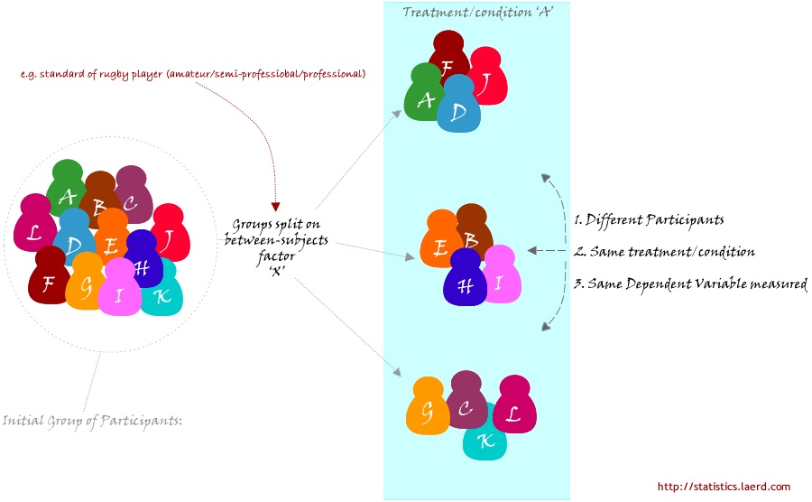

我们主要是以单因素方差分析为例介绍方差分析的基本原理。

### 0.1.1 示例

数据：

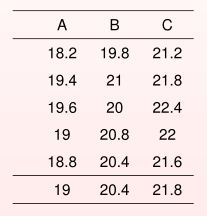

图形化：

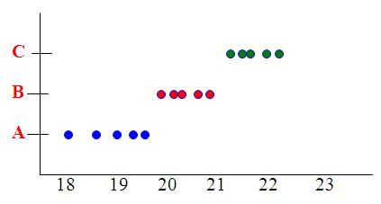

如果这个数据变化一下：

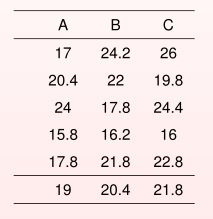

图形化：

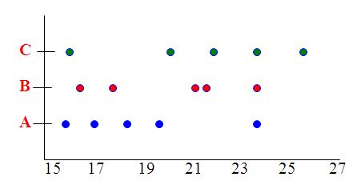

### 0.1.2 两个因素影响我们判断均值间是否有差异：

#### 0.1.2.1 均值间的差异

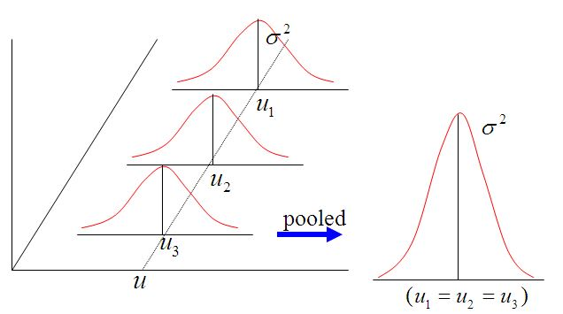

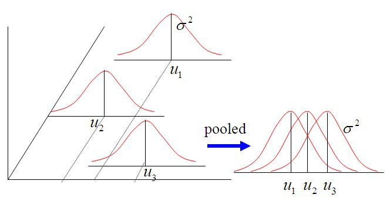

### 0.1.3 样本方差的大小

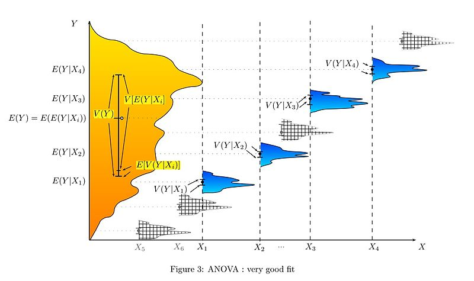

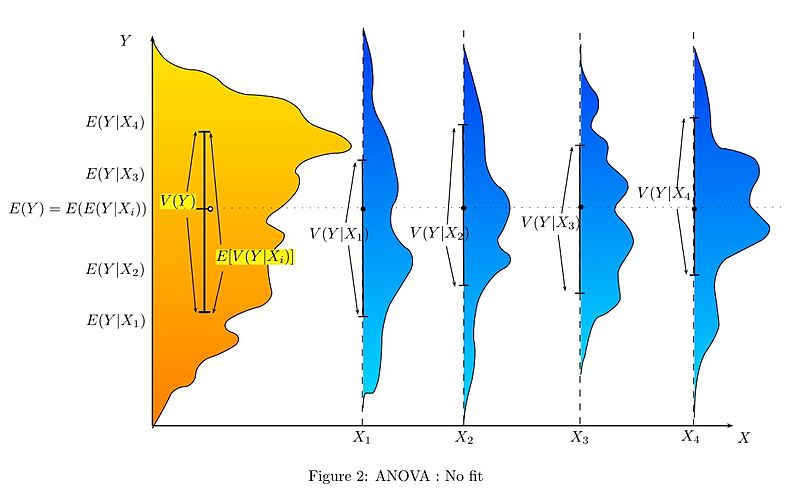

### 0.1.4 两种估计总体方差的方式

#### 0.1.4.1 基于样本方差的估计

从样本中我们可以得到多个总体方差的无偏估计值(unbiased estimator)，如对于样本一和样本二来说：

$$s_1^2=\frac{\sum_{i=1}^{n_1}(x_{i1}-\bar{x_1})^2}{n_1-1}$$

$$s_2^2=\frac{\sum_{i=1}^{n_2}(x_{i2}-\bar{x_2})^2}{n_2-1}$$

虽然各组样本的方差皆为总体方差的无偏估计式，但是更佳、更有效率的估计为充分运用 所有的样本观察值，即将各组的观察值集合起来一起得到一个混和估计值：

$$s_p^2=\frac{s_1^2(n_1-1)+s_2^2(n_2-1)+\dots+s_k^2(n_k-1)}{n_1+n_2+\dots+n_k-K}$$

可视为样本方差的加权平均值，权重为：
$$\frac{n_j-1}{n_1+n_2+\dots+n_k-K}$$

由于：

$$s_j^2=\frac{\sum_{i=1}^{n_j}(x_{ij}-\bar{x_j})^2}{n_j-1}$$
$$s_j^2=\frac{SS_{j}}{n_j-1}$$
所以：

$$s_p^2=\frac{SS_1+SS_2+\dots+SS_k}{n_1+n_2+\dots+n_k-K}$$

$$s_p^2=\frac{SS_1+SS_2+\dots+SS_k}{N-K}$$

令：
$$SSW=SS_1+SS_2+\dots+SS_k$$

则：
$$s_p^2=\frac{SSW}{N-K}$$

在这种情境下，$s_p^2$也被称为MSW (Mean Square Within)组内均方或均方误差MSE(Mean Square Error)。

$$MSW=\frac{SSW}{N-K}$$

#### 0.1.4.2 基于样本均值分布的估计

如果总体为正态分布，则样本平均数的抽样分布为：
$$\bar{x} \sim N(\mu, \frac{\sigma^2}{n})$$

将样本均值看作从样本均值分布$N(\mu, \frac{\sigma^2}{n})$中抽取的随机样本，则可估计此分布的方差：

$$s_{\bar{x}}^2=\frac{\sum_{j=1}^K(\bar{x_j}-\bar{\bar{x}})^2}{K-1}$$

根据中心极限定理，知：

$$\sigma_{\bar{x_j}}^2=\frac{\sigma^2}{n_j}$$

那么：

$$\sigma^2=n_j\sigma_{\bar{x_j}}^2$$

$\sigma^2$的估计值为：
$$\hat{\sigma}^2=n_js_{\bar{x_j}}^2$$

$$\hat{\sigma}^2=n_j\frac{\sum_{j=1}^k(\bar{x_j}-\bar{\bar{x}})^2}{K-1}$$
$$\hat{\sigma}^2=\frac{\sum_{j=1}^k n_j(\bar{x_j}-\bar{\bar{x}})^2}{K-1}$$

$$\hat{\sigma}^2=\frac{n_1(\bar{x_1}-\bar{\bar{x}})^2+n_2(\bar{x_2}-\bar{\bar{x}})^2+
\dots+n_k(\bar{x_k}-\bar{\bar{x}})^2}{K-1}$$

令：
$$SSB=n_1(\bar{x_1}-\bar{\bar{x}})^2+n_2(\bar{x_2}-\bar{\bar{x}})^2+
\dots+n_k(\bar{x_k}-\bar{\bar{x}})^2$$

则：
$$\hat{\sigma}^2=\frac{SSB}{K-1}$$

在这种情境下，$\hat{\sigma}^2$也被称为MSB (Mean Square Between)组间均方。

$$MSB=\frac{SSB}{K-1}$$

### 0.1.5 两个期望

#### 0.1.5.1 基于MSW的期望

$$\begin{align*}
MSW&=E(\frac{SSW}{N-K})\\
&=E(\frac{\sum_{j=1}^K(n_j-1)s_j^2}{N-K})\\
&=\frac{1}{N-K}E(\sum_{j=1}^K(n_j-1)s_j^2))\\
&=\frac{\sum_{j=1}^K(n_j-1)}{N-K}E(s_j^2)\\
&=\sigma^2
\end{align*}$$

#### 0.1.5.2 基于MSB的期望

$$\begin{align*}
E(n_js_{\bar{x_j}}^2)&=E(\frac{SSB}{K-1})\\
&=E(\frac{\sum_{j=1}^k n_j(\bar{x_j}-\bar{\bar{x}})^2}{K-1})\\
&=\frac{1}{K-1}E(\sum_{j=1}^k n_j(\bar{x_j}-\bar{\bar{x}})^2)\\
&=\frac{1}{K-1}E(\sum_{j=1}^k n_j \bar{x_j}^2-N \bar{\bar{x}}^2)\\
&=\frac{1}{K-1}(\sum_{j=1}^k n_j E(\bar{x_j}^2))-N E(\bar{\bar{x}}^2))
\end{align*}$$

考虑期望的定义，$E(x)=\mu=\Sigma{xf(x)}$

$E(s_2^2)$就是观测值和均值之差$(X-\mu)$的平方的期望。
$$\begin{align*}
\sigma^2&=E[(X-\mu)^2]\\
&=E(X^2-2X\mu+\mu^2)\\
&=E(X^2)-2\mu E(X)+E(\mu^2)\\
&=E(X^2)-2\mu \mu+\mu^2\\
&=E(X^2)-\mu^2\\
&=E(X^2)-[E(X)]^2
\end{align*}$$

由于：
$$\sigma_{\bar{x_j}}^2=E(\bar{x_j}^2)-[E(\bar{x_j})]^2$$

所以：

$$\begin{align*}
E(n_js_{\bar{x_j}}^2)&=\frac{1}{K-1}(\sum_{j=1}^k n_j E(\bar{x_j}^2))-N E(\bar{\bar{x}}^2))\\
&=\frac{1}{K-1}(\sum_{j=1}^k n_j (\frac{\sigma^2}{n_j}+\mu_j^2)-N (\frac{\sigma^2}{N}+\mu^2)))\\
&=\frac{1}{K-1}(\sum_{j=1}^k\sigma^2+\sum_{j=1}^k n_j\mu_j^2-\sigma^2-N\mu^2)\\
&=\frac{1}{K-1}(k\sigma^2-\sigma^2+\sum_{j=1}^k n_j\mu_j^2-N\mu^2)\\
&=\sigma^2+\frac{1}{K-1}\sum_{j=1}^k n_j(\mu_j-\mu)^2
\end{align*}$$

上式分为两部分，第一部分是$\sigma^2$，第二个部分是:
$$\frac{1}{K-1}\sum_{j=1}^k n_j(\mu_j-\mu)^2$$

### 0.1.6 比较系统差异和抽样误差

$$统计量=\frac{系统差异+抽样误差}{抽样误差}$$

对于MSW来说，其期望就是已知抽样规模情况下，反映抽样误差的总体方差$\sigma^2$。

对于MSB来说，其前一个部分是已知抽样规模情况下，反映抽样误差的总体方差$\sigma^2$，后一个部分是系统差异，如果虚无假设为真，则$\sum_{j=1}^k n_j(\mu_j-\mu)^2$为零：

$$\begin{align*}
E(n_js_{\bar{x_j}}^2)&=\sigma^2+\frac{1}{K-1}\sum_{j=1}^k n_j(\mu_j-\mu)^2\\
&=\sigma^2
\end{align*}$$
否则，
$$\begin{align*}
E(n_js_{\bar{x_j}}^2)&=\sigma^2+\frac{1}{K-1}\sum_{j=1}^k n_j(\mu_j-\mu)^2\\
&>\sigma^2
\end{align*}$$

且随着$\mu_j$与$\mu$的差距的增大而增大。

此时，我们就可以构建统计量$F$：

$$F=\frac{MSB}{MSW}$$

- F统计量服从自由度为(K-1)及(N-K)的F分布。
- 如果$H_0$为真，分子分母皆为总体方差无偏估计值，两者的比率会十分接近1，
- 如果$H_0$为不真，则MSB会高估总体方差，F值会大于1。F愈大，$H_0$愈不可能为真。

### 0.1.7 计算问题

$$(x_{ij}-\bar{\bar{x}})=(\bar{x_j}-\bar{\bar{x}})+(x_{ij}-\bar{x_j})$$

两边取平方得到：
$$\begin{equation*}
\sum_{j=1}^k \sum_{i=1}^{n_j}(x_{ij}-\bar{\bar{x}})^2=\sum_{j=1}^k \sum_{i=1}^{n_j}(\bar{x_j}-\bar{\bar{x}})^2+
\sum_{j=1}^k \sum_{i=1}^{n_j}(x_{ij}-\bar{x_j})^2+2\sum_{j=1}^k \sum_{i=1}^{n_j}(\bar{x_j}-\bar{\bar{x}})(x_{ij}-\bar{x_j})
\end{equation*}$$
可以证明第三项为零。
$$\begin{equation*}
\sum_{j=1}^k \sum_{i=1}^{n_j}(x_{ij}-\bar{\bar{x}})^2=\sum_{j=1}^k \sum_{i=1}^{n_j}(\bar{x_j}-\bar{\bar{x}})^2+
\sum_{j=1}^k \sum_{i=1}^{n_j}(x_{ij}-\bar{x_j})^2
\end{equation*}$$

- 等式左边为SST，其含义是所有的观测值与总体均值差异的平方和。
- 等式右边第一项为SSB，也称组间变异，各组均值减去总体均值的差的平方乘以$n_j$后加和。

$$SSB=n_1(\bar{x_1}-\bar{\bar{x}})^2+n_2(\bar{x_2}-\bar{\bar{x}})^2+
\dots+n_k(\bar{x_k}-\bar{\bar{x}})^{2}$$

$$SSB=\sum_{j=1}^k n_j(\bar{x_j}-\bar{\bar{x}})^2$$

- 等式右边第二项为SSW，也称组内变异，为观测值减去所在组的组均值的差的平方和，再对各组的组内平方和进行相加。

$$\begin{align*}
SSW&=\sum_{i=1}^{n_1}(x_{i1}-\bar{x_1})^2+\sum_{i=1}^{n_2}(x_{i2}-\bar{x_2})^2+\dots+
\sum_{i=1}^{n_k}(x_{ik}-\bar{x_k})^2\\
SSW&=\sum_{j=1}^k \sum_{i=1}^{n_j}(x_{ij}-\bar{x_j})\\
SSW&=SS_1+SS_2+\dots+SS_k
\end{align*}$$

- 得到F值

$$F=\frac{MSB}{MSW}$$

$$F=\frac{SSB/(K-1)}{SSW/(N-K)}$$

### 0.1.8 R中实现单因素方差分析

#### 0.1.8.1 基本代码

```r
library(car)
CarData<-read.table(file="CarData.txt",header=TRUE)
CarData$ModelYear<-as.factor(CarData$ModelYear)
aov(MPG~ModelYear,data=CarData)
```

```
## Call:
##    aov(formula = MPG ~ ModelYear, data = CarData)
##
## Terms:
##                 ModelYear Residuals
## Sum of Squares   10401.78  13850.79
## Deg. of Freedom        12       385
##
## Residual standard error: 5.998007
## Estimated effects may be unbalanced
```

```r
OneWay<-aov(MPG~ModelYear,data=CarData)
summary(OneWay)
```

```
##              Df Sum Sq Mean Sq F value Pr(>F)
## ModelYear    12  10402   866.8   24.09 <2e-16 ***
## Residuals   385  13851    36.0
## ---
## Signif. codes:  0 '***' 0.001 '**' 0.01 '*' 0.05 '.' 0.1 ' ' 1
```

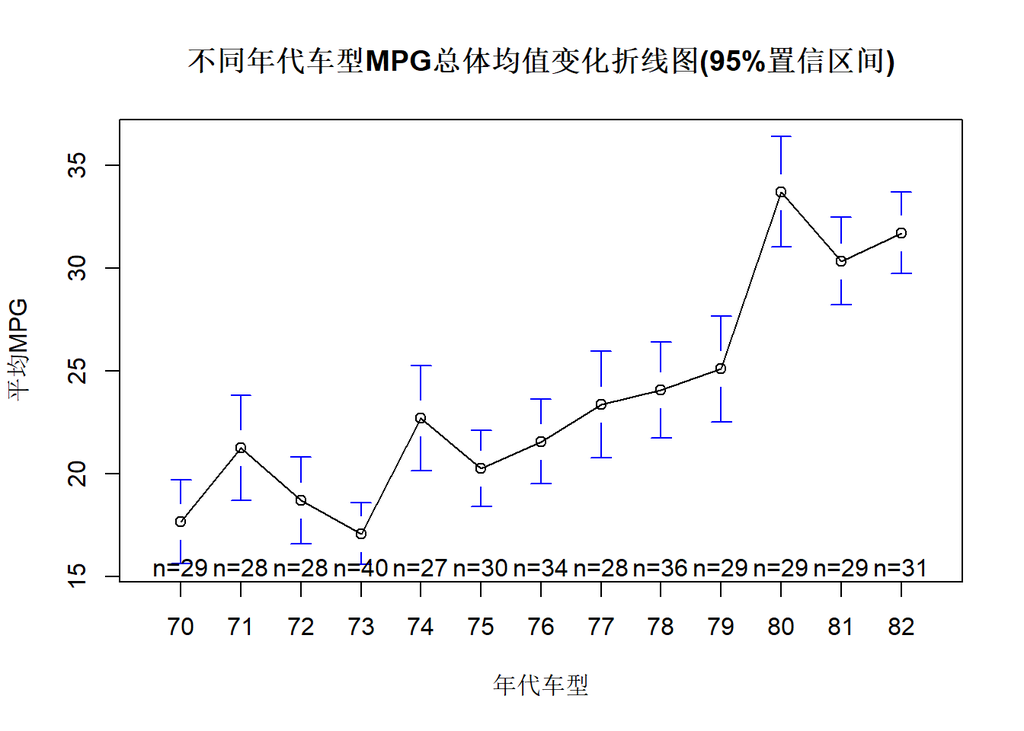

```r
# install.packages("gplots")
library("gplots")
plotmeans(MPG~ModelYear,data=CarData,p=0.95,use.t=TRUE,xlab="年代车型",ylab="平均MPG",main="不同年代车型MPG总体均值变化折线图(95%置信区间)")
```

#### 0.1.8.2 正态性检验

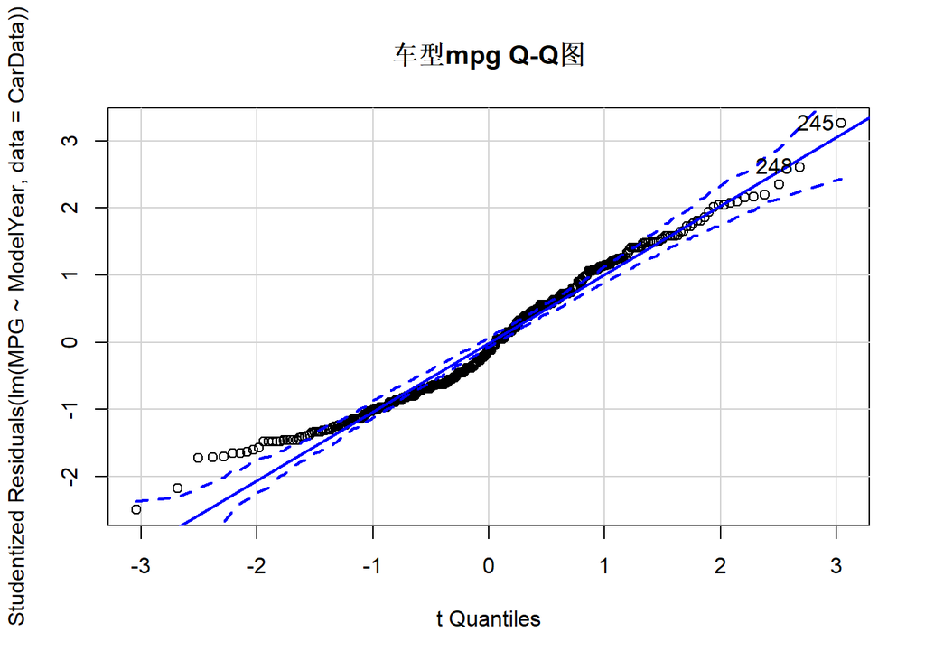

```
## [1] 245 248
```

```r
library(car)
 qqPlot(lm(MPG ~ ModelYear, data = CarData), simulate = TRUE,
    main = "车型mpg Q-Q图", labels = FALSE)
```

#### 0.1.8.3 方差齐性检验

```r
leveneTest(CarData$MPG,CarData$ModelYear, center=mean)
```

```
## Levene's Test for Homogeneity of Variance (center = mean)
##        Df F value  Pr(>F)
## group  12  1.7173 0.06103 .
##       385
## ---
## Signif. codes:  0 '***' 0.001 '**' 0.01 '*' 0.05 '.' 0.1 ' ' 1
```

```r
bartlett.test(MPG ~ ModelYear, data = CarData)
```

```
##
##  Bartlett test of homogeneity of variances
##
## data:  MPG by ModelYear
## Bartlett's K-squared = 13.32, df = 12, p-value = 0.3462
```

#### 0.1.8.4 事后检验

```r
OneWay<-aov(MPG~ModelYear,data=CarData)
OneWay$coefficients
```

```
## (Intercept) ModelYear71 ModelYear72 ModelYear73 ModelYear74 ModelYear75
##  17.6896552   3.5603448   1.0246305  -0.5896552   5.0140485   2.5770115
## ModelYear76 ModelYear77 ModelYear78 ModelYear79 ModelYear80 ModelYear81
##   3.8838742   5.6853448   6.3714559   7.4034483  16.0068966  12.6448276
## ModelYear82
##  14.0200222
```

```r
TukeyHSD(OneWay,ordered=FALSE,conf.level=0.95)
```

```
##   Tukey multiple comparisons of means
##     95% family-wise confidence level
##
## Fit: aov(formula = MPG ~ ModelYear, data = CarData)
##
## $ModelYear
##             diff          lwr        upr     p adj
## 71-70  3.5603448 -1.737584676  8.8582743 0.5621668
## 72-70  1.0246305 -4.273298962  6.3225600 0.9999872
## 73-70 -0.5896552 -5.466537903  4.2872276 0.9999999
## 74-70  5.0140485 -0.333563533 10.3616606 0.0912557
## 75-70  2.5770115 -2.630295013  7.7843180 0.9127501
## 76-70  3.8838742 -1.170630163  8.9383786 0.3375465
## 77-70  5.6853448  0.387415324 10.9832743 0.0229529
## 78-70  6.3714559  1.382000010 11.3609119 0.0018064
## 79-70  7.4034483  2.152197475 12.6546991 0.0002657
## 80-70 16.0068966 10.755645751 21.2581474 0.0000000
## 81-70 12.6448276  7.393576785 17.8960784 0.0000000
## 82-70 14.0200222  8.854163329 19.1858812 0.0000000
## 72-71 -2.5357143 -7.879914795  2.8084862 0.9346549
## 73-71 -4.1500000 -9.077109418  0.7771094 0.2028000
## 74-71  1.4537037 -3.939753151  6.8471606 0.9995585
## 75-71 -0.9833333 -6.237708949  4.2710423 0.9999911
## 76-71  0.3235294 -4.779453717  5.4265125 1.0000000
## 77-71  2.1250000 -3.219200509  7.4692005 0.9832509
## 78-71  2.8111111 -2.227449449  7.8496717 0.8173683
## 79-71  3.8431034 -1.454826056  9.1410330 0.4332907
## 80-71 12.4465517  7.148622220 17.7444812 0.0000000
## 81-71  9.0844828  3.786553255 14.3824123 0.0000017
## 82-71 10.4596774  5.246375163 15.6729797 0.0000000
## 73-72 -1.6142857 -6.541395133  3.3128237 0.9970015
## 74-72  3.9894180 -1.404038865  9.3828748 0.4003741
## 75-72  1.5523810 -3.701994664  6.8067566 0.9988922
## 76-72  2.8592437 -2.243739431  7.9622268 0.8129522
## 77-72  4.6607143 -0.683486224 10.0049148 0.1605944
## 78-72  5.3468254  0.308264837 10.3853860 0.0262006
## 79-72  6.3788177  1.080888230 11.6767472 0.0047586
## 80-72 14.9822660  9.684336506 20.2801955 0.0000000
## 81-72 11.6201970  6.322267540 16.9181265 0.0000000
## 82-72 12.9953917  7.782089449 18.2086940 0.0000000
```

[output cut: 30 more lines]

```
## 78-77  0.6861111 -4.352449449  5.7246717 0.9999998
## 79-77  1.7181034 -3.579826056  7.0160330 0.9972771
## 80-77 10.3215517  5.023622220 15.6194812 0.0000000
## 81-77  6.9594828  1.661553255 12.2574123 0.0010853
## 82-77  8.3346774  3.121375163 13.5479797 0.0000128
## 79-78  1.0319923 -3.957463592  6.0214483 0.9999732
## 80-78  9.6354406  4.645984684 14.6248965 0.0000000
## 81-78  6.2733716  1.283915719 11.2628276 0.0023594
## 82-78  7.6485663  2.749062879 12.5480697 0.0000240
## 80-79  8.6034483  3.352197475 13.8546991 0.0000065
## 81-79  5.2413793 -0.009871491 10.4926301 0.0509588
## 82-79  6.6165740  1.450715053 11.7824329 0.0017136
## 81-80 -3.3620690 -8.613319767  1.8891818 0.6394647
## 82-80 -1.9868743 -7.152733223  3.1789846 0.9873448
## 82-81  1.3751947 -3.790664258  6.5410536 0.9996110
```

```r
# Result<-TukeyHSD(OneWay,ordered=TRUE,conf.level=0.95)
```

## 0.2 回归分析

### 0.2.1 方差分析和回归分析的异同

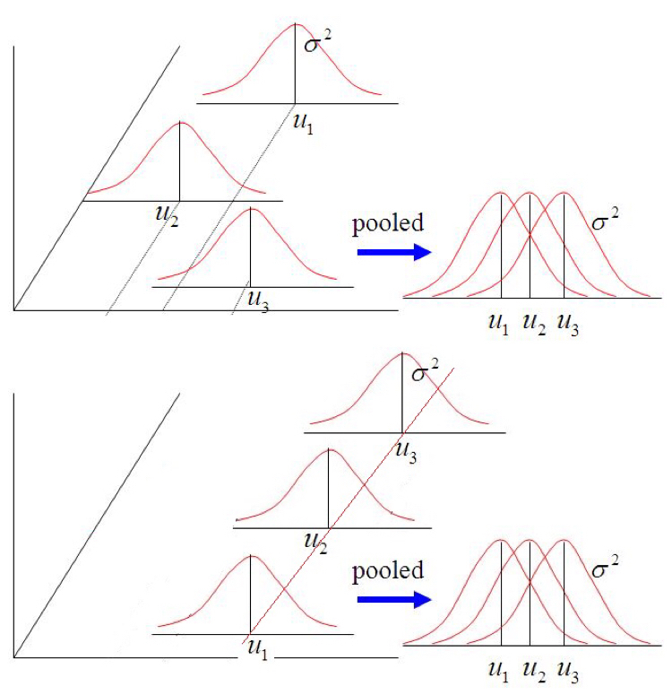

回归和方差分析的异同在于：

- 方差分析的分组变量是因子(factor)，因子可以是有序的，有可以是无序的，但是回归分析中的自变量是scale的，可以在一个量尺上平滑游走。

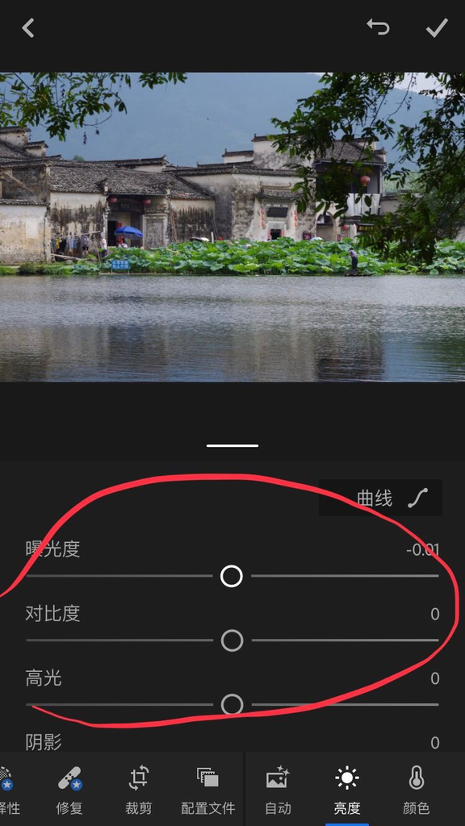

- 方差分析猜测组均值与组均值之间有差异，但是对哪组均值大哪组均值小没有假设。
- 和方差分析相同的是，回归分析也猜测组均值之间有差异，而且猜测可能x越大，组均值越小；或者，x越小，组均值越大。
- 回归分析还猜测，组均值变大或者变小的速度是固定的，即线性的：

$$\frac{y_2-y_1}{x_2-x_1}=\frac{y_3-y_2}{x_3-x_2}$$

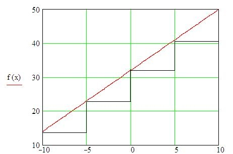

- 这种情况下，如果组均值间有差异，那么在x轴上任意取两个x值，只要其相对应的y的组均值有差异，则所有的组均值间都有差异。
- 同时，我们在二维坐标系上，将x和对应的组均值连成一条线，这条线的斜率也不为0。因若斜率为0，则各组均值就相同了。
- 这条线就是回归线，这条线上的纵坐标就是给定x时，y的分布的均值。

### 0.2.2 关于回归的误区

- 说到回归，容易想到这样一条线：

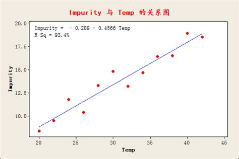

- 似乎把x和y在坐标系里标记出来，然后“瞄”出来一条线就是回归线。这种图主要是数据量小，数据量大了之后，看到的散点图是这样：

[figure not shown]

- 给定x的值后，有很多y值与之对应：

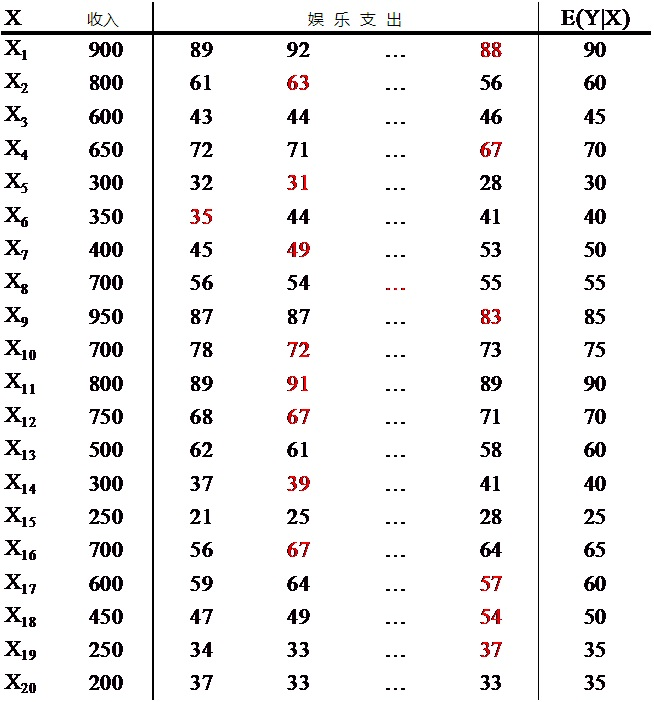

- y是x的条件分布，换言之，y就是方差分析中的一组一组的数据，x是分组变量，只是这个分组变量是连续的。
- 一般化的话，是这样：

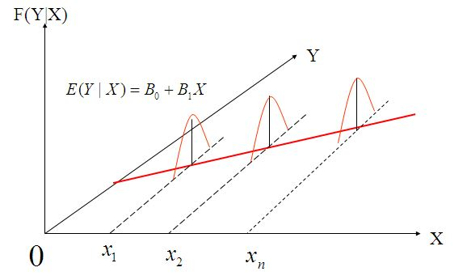

或者这样:

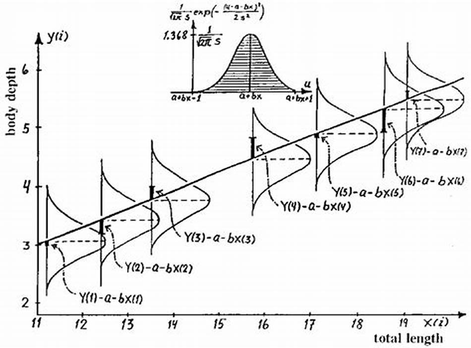

- 既然y是给定x的条件分布，那么这个分布是什么形态呢？它的期望和方差又是什么？
  - 正态分布（回归分析的假设之一：y服从正态分布）
  - 均值就是预测值，也就是组均值（回归分析的假设之一，残差均值为0），而且x不同，组均值也不同
  - 虽然各条件分布的组均值不同，但是方差相同（回归分析的假设之一：齐方差）

### 0.2.3 到底均值间有没有差异？

我们可以继续方差分析的思路，方差分析里是通过下面公式来判断的：

$$F=\frac{MSB}{MSW}$$

回归分析也一样，只是把符号换一下：

$$F=\frac{MSR}{MSE}$$

还是可以认为有两种方式估计总体方差，一种是计算样本方差的加权平均值，一种是基于均值抽样分布。第二种方法里，如果虚无假设为真，则其对总体方差的估计应该接近第一种方法。

方差分析的计算，需要观测值$x_{ij}$、组均值$\bar{x_j}$和总的均值$\bar{\bar{x}}$，对回归分析来说，$y_{ij}$和$\bar{\bar{y}}$都已知，只是$\bar{y_j}$不知道。

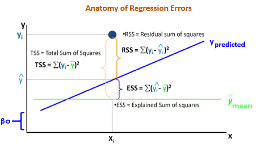

- 有的同学可能会问，$\bar{y_j}$也可以计算出来。
- 需要注意的是，方差分析中对组均值没有假设，但是回归分析则假设组均值一定在回归线上，这才是期望的均值。
- 如果我们知道了给定x时候，y的期望，也就是预测值$\hat{y}$（即给定x时候，y的条件分布的均值{y_j}$），就可以计算：

$$F=\frac{MSR}{MSE}$$

- 如果我们知道了回归线的位置，自然可以计算$\hat{y}$，所以求解$\hat{y}$就变成了对回归系数的求解。

### 0.2.4 估计回归系数的方法

回归系数的估计有许多种方法，最常用的为最小二乘法(ordinary least squares method, OLS)及最大似然法(Maximum likelihood method)，我们的目标是要找出一条线，使每一个观察值与预测值的距离的平方和最小。

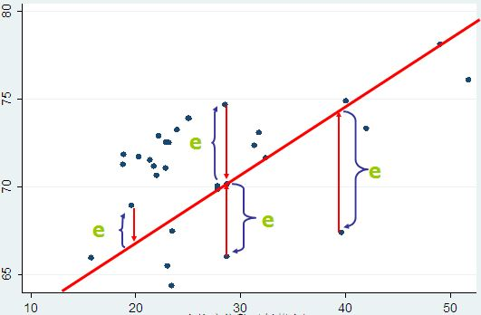

由于残差值有正有负，无法正确测量出两者的距离，因此将残差值加以平方。即$(e_i^2+e_2^2+e_3^2+\dots+e_n^2)$的值最小。

$$\begin{align*}
SSE&=(e_i^2+e_2^2+e_3^2+\dots+e_n^2)\\
&=\sum_{i=1}^n(e_i^2)\\
&=\sum_{i=1}^n(y_i-\hat{y_i})^2\\
&=\sum_{i=1}^n(y_i-b_0-b_1x_i)^2
\end{align*}$$

这样就变成了一个极值问题，f(x)的极小值出现在切线斜率等于零的时候。

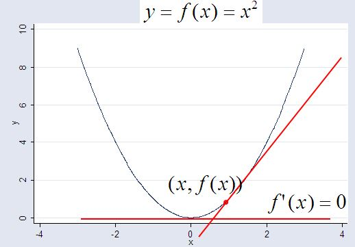

$\frac{\partial SSE}{\partial b_0}=0$且$\frac{\partial SSE}{\partial b_1}=0$时，SSE有最小值。

令$a=b_0$，$b=b_1$，

$$\begin{align*}
SSE&=\sum_{i=1}^n(y_i-b_0-b_1x_i)^2\\
&=(y_1-a-bx_i)^2+(y_2-a-bx_2)^2+\dots+(y_n-a-bx_n)^2
\end{align*}$$

对$a$求微分：

$$2(y_1-a-bx_1)(-1)+2(y_2-a-bx_2)(-1)+\dots+2(y_n-a-bx_n)(-1)=0$$

$$(a+a+\dots+a)+b(x_1+x_2+\dots+x_n)=y_1+y_2+\dots+y_n$$

$$na+b\sum x_i=\sum y_i$$

两边除以n，
$$a+b\bar{x}=\bar{y}$$

所以，
$$a=\bar{y}-b\bar{x}$$

对$b$求微分：
$$2(y_1-a-bx_1)(-x_1)+2(y_2-a-bx_2)(-x_2)+\dots+2(y_n-a-bx_n)(-x_n)=0$$
$$a(x_1+x_2+\dots+x_n)+b(x_1^2+x_2^2+\dots+x_n^2)=x_1y_1+x_2y_2+\dots+x_ny_n$$

$$a\sum x_i+b\sum x_i^2=\sum x_iy_i$$

由于
$$a=\bar{y}-b\bar{x}=\frac{\sum y_i}{n}-b\frac{\sum x_i}{n}$$

所以，
$$(\frac{\sum y_i}{n}-b\frac{\sum x_i}{n})\sum x_i+b\sum x_i^2=\sum x_iy_i$$

$$\frac{\sum y_i}{n}-b\frac{\sum x_i}{n})\sum x_i+b\sum x_i^2=\sum x_iy_i$$

$$\frac{\sum x_i \sum y_i}{n}-b\frac{(\sum x_i)^2}{n}+b\sum x_i^2=\sum x_iy_i$$

$$b(\sum x_i^2-\frac{(\sum x_i)^2}{n})=\sum x_iy_i-\frac{\sum x_i \sum y_i}{n}$$

$$\begin{equation*}
b=\frac{\sum x_iy_i-\frac{\sum x_i \sum y_i}{n}}{\sum x_i^2-\frac{(\sum x_i)^2}{n}}
\end{equation*}$$

知道了系数，就可以计算$\hat{y}$，然后就可以计算$F$值了。

### 0.2.5 多自变量回归方程

多自变量回归一般叫muliple regression，是在一个多维空间里的回归。

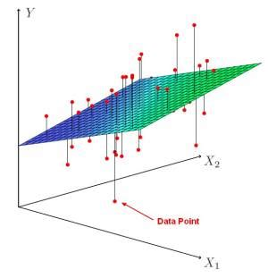

#### 0.2.5.1 线性回归方程的建立

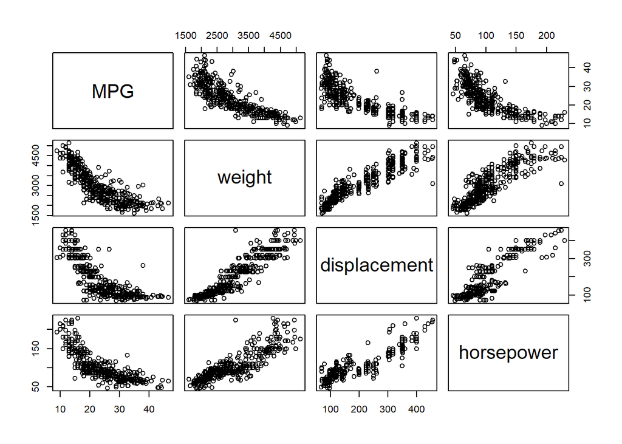

```r
CarData<-read.table(file="CarData.txt",header=TRUE)
CarData$ModelYear<-as.factor(CarData$ModelYear)
pairs(~MPG+weight+displacement+horsepower,data=CarData)
```

```r
Fit<-lm(MPG~weight+displacement+horsepower,data=CarData)
```

```r
coefficients(Fit)
```

```
##  (Intercept)       weight displacement   horsepower
## 44.855935695 -0.005351593 -0.005768819 -0.041674144
```

#### 0.2.5.2 显著性检验和调整

```r
summary(Fit)
```

```
##
## Call:
## lm(formula = MPG ~ weight + displacement + horsepower, data = CarData)
##
## Residuals:
##      Min       1Q   Median       3Q      Max
## -11.3347  -2.8028  -0.3402   2.2037  16.2409
##
## Coefficients:
##                Estimate Std. Error t value Pr(>|t|)
## (Intercept)  44.8559357  1.1959200  37.507  < 2e-16 ***
## weight       -0.0053516  0.0007124  -7.513 4.04e-13 ***
## displacement -0.0057688  0.0065819  -0.876  0.38132
## horsepower   -0.0416741  0.0128139  -3.252  0.00125 **
## ---
## Signif. codes:  0 '***' 0.001 '**' 0.01 '*' 0.05 '.' 0.1 ' ' 1
##
## Residual standard error: 4.241 on 388 degrees of freedom
##   (6 observations deleted due to missingness)
## Multiple R-squared:  0.707,  Adjusted R-squared:  0.7047
## F-statistic:   312 on 3 and 388 DF,  p-value: < 2.2e-16
```

```r
confint(Fit)
```

```
##                    2.5 %       97.5 %
## (Intercept)  42.50464109 47.207230298
## weight       -0.00675215 -0.003951036
## displacement -0.01870945  0.007171815
## horsepower   -0.06686744 -0.016480849
```

```r
Fit<-lm(MPG~weight+horsepower,data=CarData)
summary(Fit)
```

```
##
## Call:
## lm(formula = MPG ~ weight + horsepower, data = CarData)
##
## Residuals:
##      Min       1Q   Median       3Q      Max
## -11.0762  -2.7340  -0.3312   2.1752  16.2601
##
## Coefficients:
##               Estimate Std. Error t value Pr(>|t|)
## (Intercept) 45.6402108  0.7931958  57.540  < 2e-16 ***
## weight      -0.0057942  0.0005023 -11.535  < 2e-16 ***
## horsepower  -0.0473029  0.0110851  -4.267 2.49e-05 ***
## ---
## Signif. codes:  0 '***' 0.001 '**' 0.01 '*' 0.05 '.' 0.1 ' ' 1
##
## Residual standard error: 4.24 on 389 degrees of freedom
##   (6 observations deleted due to missingness)
## Multiple R-squared:  0.7064, Adjusted R-squared:  0.7049
## F-statistic: 467.9 on 2 and 389 DF,  p-value: < 2.2e-16
```

#### 0.2.5.3 预测值

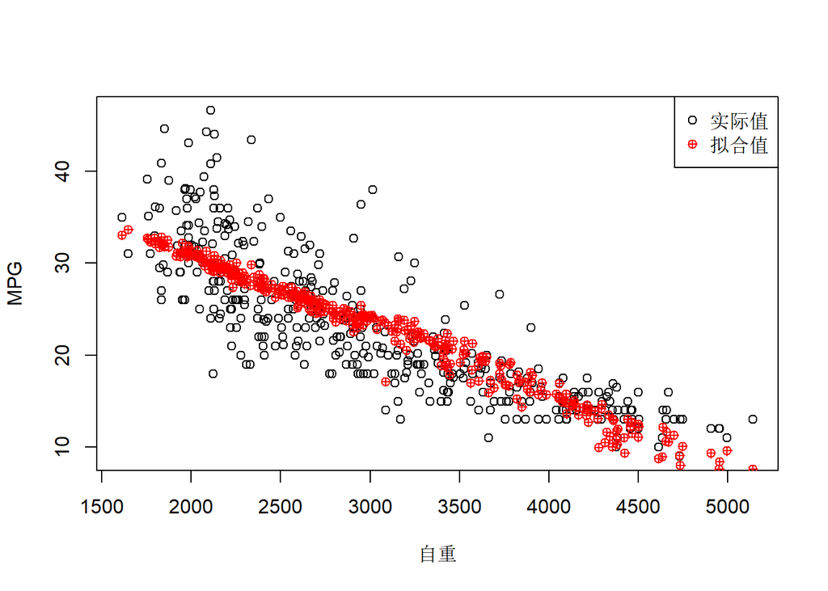

```r
FitMPG<-predict(Fit,CarData,type="response")
plot(CarData$weight,CarData$MPG,pch=1,xlab="自重",ylab="MPG")
points(CarData$weight,FitMPG,pch=10,col=2)
legend("topright",c("实际值","拟合值"),pch=c(1,10),col=c(1,2))
```

#### 0.2.5.4 残差是否正态？

```r
fitted(Fit)
```

[output not shown]

[output cut: 57 more lines]

[output not shown]

```r
residuals(Fit)
```

[output not shown]

[output cut: 103 more lines]

[output not shown]

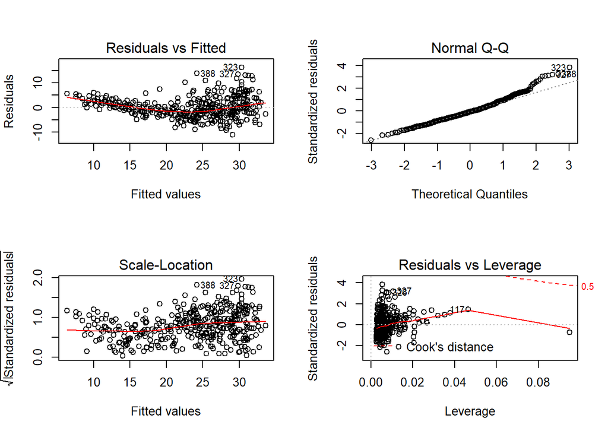

```r
par(mfrow=c(2,2))
plot(Fit)
```

因变量做BOX-COX变换，BOX-COX变换是指$y^{\lambda}$，常见的是对数转换。

```r
Fit<-lm(log(MPG)~weight+horsepower,data=CarData)
summary(Fit)
```

```
##
## Call:
## lm(formula = log(MPG) ~ weight + horsepower, data = CarData)
##
## Residuals:
##      Min       1Q   Median       3Q      Max
## -0.45865 -0.09660 -0.00648  0.10038  0.49885
##
## Coefficients:
##               Estimate Std. Error t value Pr(>|t|)
## (Intercept)  4.1109472  0.0293674 139.983  < 2e-16 ***
## weight      -0.0002504  0.0000186 -13.462  < 2e-16 ***
## horsepower  -0.0025573  0.0004104  -6.231  1.2e-09 ***
## ---
## Signif. codes:  0 '***' 0.001 '**' 0.01 '*' 0.05 '.' 0.1 ' ' 1
##
## Residual standard error: 0.157 on 389 degrees of freedom
##   (6 observations deleted due to missingness)
## Multiple R-squared:  0.7879, Adjusted R-squared:  0.7869
## F-statistic: 722.7 on 2 and 389 DF,  p-value: < 2.2e-16
```

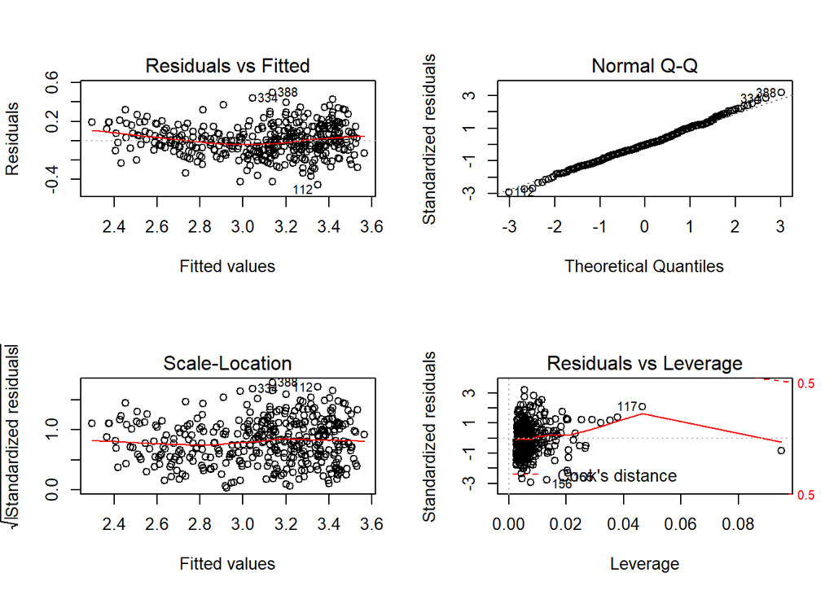

```r
par(mfrow=c(2,2))
plot(Fit)
```

也可以用*car*包中的**powerTransform**函数，估计$\lambda$的值。

```r
library("car")
summary(powerTransform(CarData$MPG))
```

```
## bcPower Transformation to Normality
##             Est Power Rounded Pwr Wald Lwr Bnd Wald Upr Bnd
## CarData$MPG    0.1974           0      -0.0907       0.4854
##
## Likelihood ratio test that transformation parameter is equal to 0
##  (log transformation)
##                            LRT df    pval
## LR test, lambda = (0) 1.809026  1 0.17863
##
## Likelihood ratio test that no transformation is needed
##                            LRT df       pval
## LR test, lambda = (1) 29.35683  1 6.0204e-08
```

```r
Fit<-lm(sqrt(MPG)~weight+horsepower,data=CarData)
summary(Fit)
```

```
##
## Call:
## lm(formula = sqrt(MPG) ~ weight + horsepower, data = CarData)
##
## Residuals:
##     Min      1Q  Median      3Q     Max
## -1.1220 -0.2632 -0.0288  0.2399  1.3180
##
## Coefficients:
##               Estimate Std. Error t value Pr(>|t|)
## (Intercept)  7.124e+00  7.490e-02  95.114  < 2e-16 ***
## weight      -5.987e-04  4.743e-05 -12.622  < 2e-16 ***
## horsepower  -5.417e-03  1.047e-03  -5.175 3.65e-07 ***
## ---
## Signif. codes:  0 '***' 0.001 '**' 0.01 '*' 0.05 '.' 0.1 ' ' 1
##
## Residual standard error: 0.4004 on 389 degrees of freedom
##   (6 observations deleted due to missingness)
## Multiple R-squared:  0.7527, Adjusted R-squared:  0.7514
## F-statistic:   592 on 2 and 389 DF,  p-value: < 2.2e-16
```

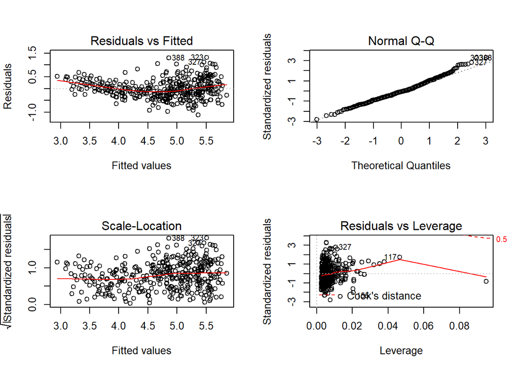

```r
par(mfrow=c(2,2))
plot(Fit)
```

#### 0.2.5.5 残差是否齐方差？

可以观察图形，也可以用*car*包中的**spreadLevelPlot**函数，**spreadLevelPlot**函数会给出$\lambda$的建议值。

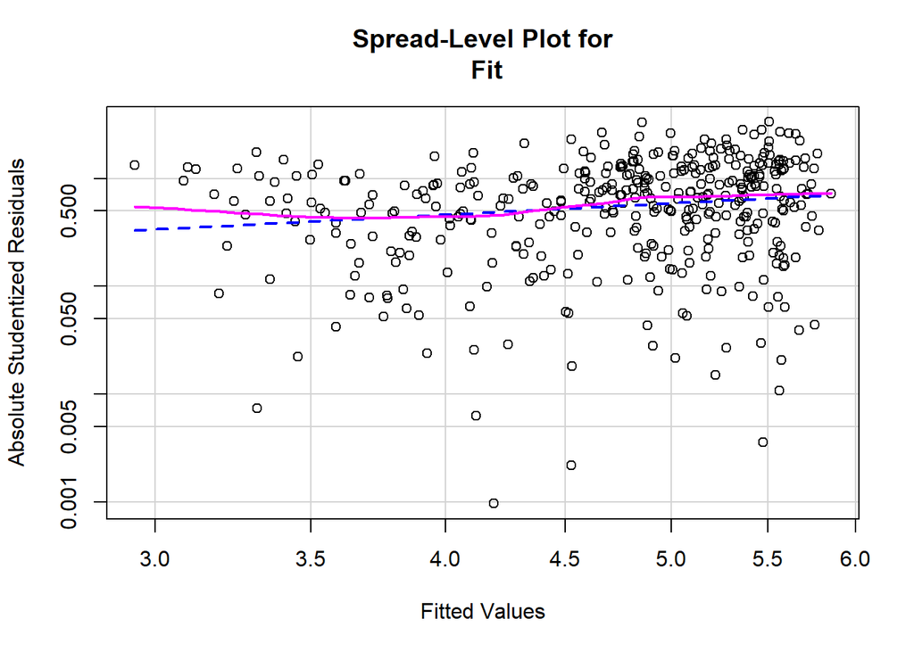

```
##
## Suggested power transformation:  -0.0929167
```

```r
Fit<-lm(sqrt(MPG)~weight+horsepower,data=CarData)
spreadLevelPlot(Fit)
```

#### 0.2.5.6 残差是否独立？

DW检验在截面数据中意义不大。

```r
library("car")
durbinWatsonTest(Fit)    ##独立性检验
```

```
##  lag Autocorrelation D-W Statistic p-value
##    1       0.5706091     0.8544013       0
##  Alternative hypothesis: rho != 0
```

#### 0.2.5.7 高杠杆值的探测

杠杆值是针对X而言的，指其取值对y的影响较大，使用函数**hatvalues**。

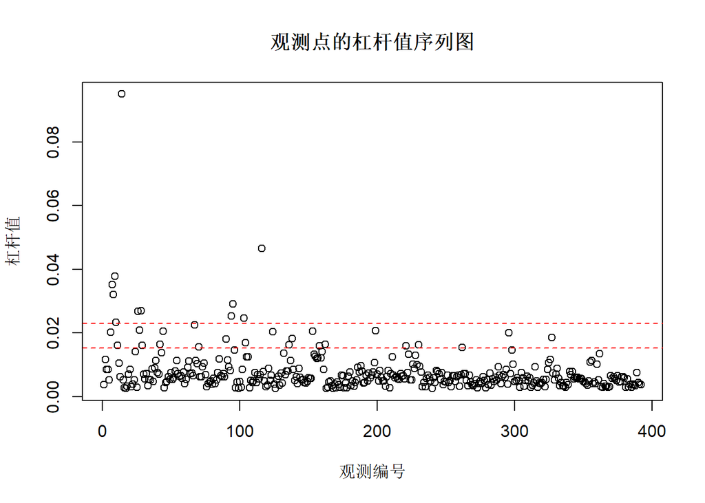

```
## integer(0)
```

```r
LeveragePlot<-function(fit){
 Np<-length(coefficients(fit))-1
 N<-length(fitted(fit))
 plot(hatvalues(fit),main="观测点的杠杆值序列图",ylab="杠杆值",xlab="观测编号")
 abline(2*(Np+1)/N,0,col="red",lty=2)
 abline(3*(Np+1)/N,0,col="red",lty=2)
 identify(1:N,hatvalues(fit),names(hatvalues(fit)))
}
Fit<-lm(sqrt(MPG)~weight+horsepower,data=CarData)
LeveragePlot(Fit)
```

#### 0.2.5.8 离群点的探测

离群点是针对y而言的。可以用图形的方法观察，也可以用学生化残差的值做判断，用*car*包中的**outlierTest**函数。

```r
Fit<-lm(log(MPG)~weight+horsepower,data=CarData)
rstudent(Fit)
```

[output not shown]

[output cut: 103 more lines]

[output not shown]

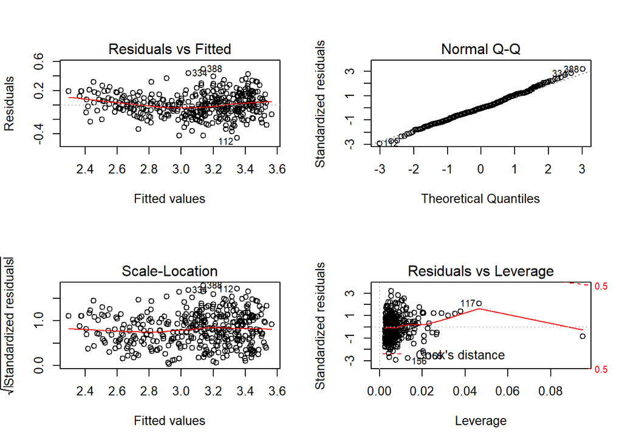

```r
par(mfrow=c(2,2))
plot(Fit)
```

```r
library("car")
outlierTest(Fit)
```

```
## No Studentized residuals with Bonferonni p < 0.05
## Largest |rstudent|:
##     rstudent unadjusted p-value Bonferonni p
## 388 3.224743          0.0013677      0.53613
```

第388个case可能是离群点，删除掉后在进行检验：

```r
Fit<-lm(log(MPG)~weight+horsepower,data=CarData[-388,])
outlierTest(Fit)
```

```
## No Studentized residuals with Bonferonni p < 0.05
## Largest |rstudent|:
##      rstudent unadjusted p-value Bonferonni p
## 112 -2.999241          0.0028815           NA
```

又发现第112个case可能是离群点。